# Non-Religious vs Religious/Spiritual

## Setup

### Load packages

```r
library(ggplot2)
library(dplyr)
library(statsr)
library(tidyr)
library(rmarkdown)
library(vcd)
library(treemap)
```

### Load data

```r
# Import the dataset
religiosity_data <- read.csv("religion-survey-results.csv")

# Identify the character columns
char_cols <- sapply(religiosity_data, is.character)

# Convert character columns to factors (if necessary) for easier analysis
religiosity_data[char_cols] <- lapply(religiosity_data[char_cols], as.factor)
```

## Part 1: Data

#### (Plan Phase of the PACE Framework)

### How are the observations in the sample collected?

The sample observations were gathered using SurveyMonkey and are assumed to be randomly selected. However, the specific details of the data collection process remain unknown and therefore this analysis is for educational purposes only.

## Part 2: Research question

#### (Plan Phase of the PACE Framework)

### Project Scope

Begin by identifying the percentage of the observed samples that hold religious or spiritual beliefs. Next, assess whether this proportion accurately reflects the larger population and whether the majority of individuals in this population are religious or spiritual.

## Part 3: Exploratory data analysis

#### (Analyze Phase of the PACE Framework)

### Initial Investigation of the Dataset

```r
# Investigate the Dataset
head(religiosity_data$What.is.your.present.religion..if.any.)
```

```
## [1] Response      None of these Atheist       Protestant    Muslim
## [6] None of these
## 12 Levels: Agnostic Atheist Buddhist Hindu Jewish Mormon ... Roman Catholic
```

```r
tail(religiosity_data$What.is.your.present.religion..if.any.)
```

```
## [1] None of these  Roman Catholic None of these  Buddhist       Roman Catholic
## [6] Atheist
## 12 Levels: Agnostic Atheist Buddhist Hindu Jewish Mormon ... Roman Catholic
```

```r
# Investigate the Variables
summary(religiosity_data$What.is.your.present.religion..if.any.)
```

```
##           Agnostic            Atheist           Buddhist              Hindu
##                123                111                 14                  6
##             Jewish             Mormon             Muslim      None of these
##                 41                 12                 11                242
## Orthodox Christian         Protestant           Response     Roman Catholic
##                 53                234                  1                192
```

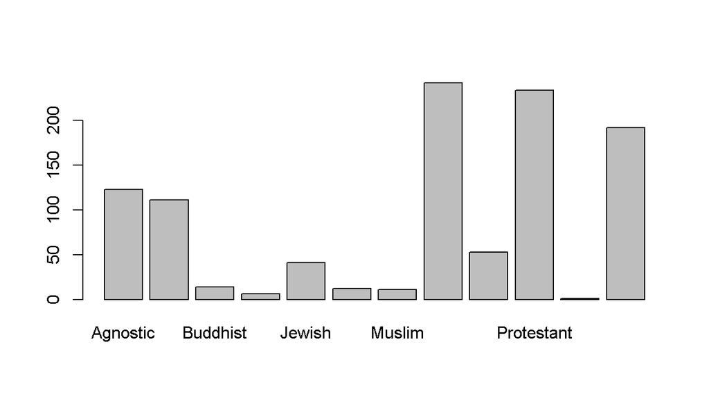

```r
barplot(table(religiosity_data$What.is.your.present.religion..if.any.))
```

### Data Manipulation and Cleaning

```r
# Remove the first row, which includes a redundant Response header.
religiosity_data_trimmed <- religiosity_data[-1, ]

# Check for Missing Values
sum(is.na(religiosity_data_trimmed))
```

```
## [1] 0
```

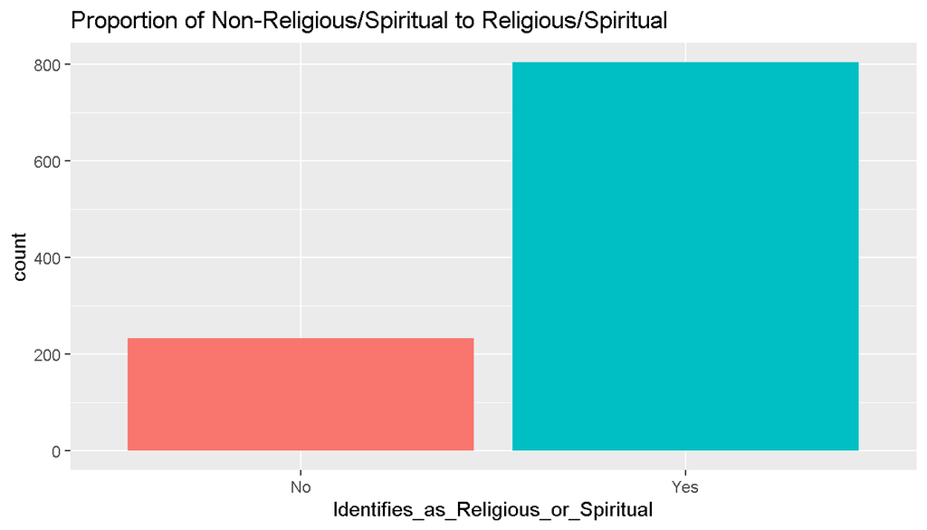

```r
# Rename Column Header for Readability
colnames(religiosity_data_trimmed) <- c("Identifies_as_Religious_or_Spiritual")

# Keep columns for analysis
religiosity_data_trimmed <- religiosity_data_trimmed %>%
  select(c("Identifies_as_Religious_or_Spiritual"))

# Rename values to Yes if religious or No if they identify as atheist
religiosity_data_cleaned <- religiosity_data_trimmed %>%
  mutate(
    Identifies_as_Religious_or_Spiritual = case_match(
      Identifies_as_Religious_or_Spiritual,
      "Atheist" ~ "No",
      "Agnostic" ~ "No",
      .default = "Yes")
  )

# Visualize the cleaned data
ggplot(religiosity_data_cleaned, aes(x = Identifies_as_Religious_or_Spiritual, fill = Identifies_as_Religious_or_Spiritual)) +
  geom_bar() +
  ggtitle("Proportion of Non-Religious/Spiritual to Religious/Spiritual") +
  theme(legend.position = "none")
```

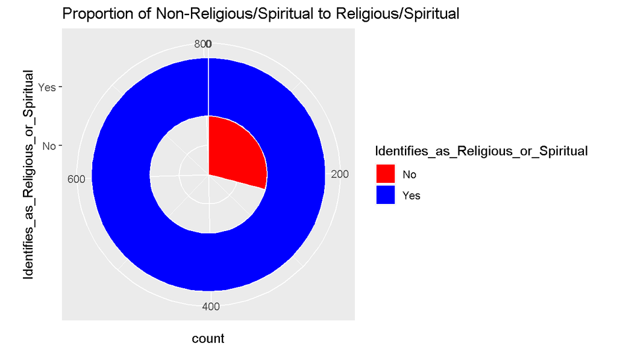

```r
ggplot(religiosity_data_cleaned, aes(x = Identifies_as_Religious_or_Spiritual, fill = Identifies_as_Religious_or_Spiritual)) +
  geom_bar(width = 1, color = "white") +
  coord_polar(theta = "y") +
  scale_fill_manual(values = c("red", "blue", "green")) +
  ggtitle("Proportion of Non-Religious/Spiritual to Religious/Spiritual")
```

### Conditions

#### Hypothesis Test for a Proportion

1. Independence: 1039 < 10% of the Population, and SurveyMonkey responses were collected randomly. Whether one individual in the sample has is religious is independent of another.
2. Sample size / skew: 1039 x 0.5 = 519.50 > 10 S-F condition met → nearly normal sampling distribution

```r
table(religiosity_data_cleaned$Identifies_as_Religious_or_Spiritual)
```

```
##
##  No Yes
## 234 805
```

```r
prop.table(table(religiosity_data_cleaned$Identifies_as_Religious_or_Spiritual))
```

```
##
##        No       Yes
## 0.2252166 0.7747834
```

## Part 4: Modeling/Inference

### Hypothesis Test (Binomial) and Confidence Intervals

H0: p < 0.5 HA: p > 0.5

```r
# Calculate the margin of error for a 95% confidence interval
(margin_of_error <- qnorm(0.975) * sqrt(0.7747834 * (1 - 0.7747834) / 1039))
```

```
## [1] 0.02539982
```

```r
# Calculate Confidence Interval
conf.int <- prop.test(x = 805, n = 1039, conf.level = 0.95)$conf.int
conf.int
```

```
## [1] 0.7478995 0.7996047
## attr(,"conf.level")
## [1] 0.95
```

```r
# Perform a z-test for a proportion
prop.test(805, 1039, p = 0.5, alternative = "greater")
```

```
##
##  1-sample proportions test with continuity correction
##
## data:  805 out of 1039, null probability 0.5
## X-squared = 312.7, df = 1, p-value < 2.2e-16
## alternative hypothesis: true p is greater than 0.5
## 95 percent confidence interval:
##  0.7522733 1.0000000
## sample estimates:
##         p
## 0.7747834
```

```r
# Perform a binomial test for a proportion
binom.test(805, 1039, p = 0.5, alternative = "greater")
```

```
##
##  Exact binomial test
##
## data:  805 and 1039
## number of successes = 805, number of trials = 1039, p-value < 2.2e-16
## alternative hypothesis: true probability of success is greater than 0.5
## 95 percent confidence interval:
##  0.7524208 1.0000000
## sample estimates:
## probability of success
##              0.7747834
```

With a 95% confidence interval, we estimate that 75% to 80% of the population is either Religious or Spiritual, with a margin of error of approximately 2.5%.

Since the p-value is less than the significance level of 0.05, we can reject the null hypothesis. This means that we have sufficient evidence to conclude that the proportion of people that are religious or spiritual is greater than 50%, or the majority.

## Part 5: Prediction/Conclusion

### What Story does the Data Tell?

The analysis of the population sample suggests that a majority of the people are religious or spiritual to some degree.